# **Lab 7: Simulating Data using an R Function**

Biostatistics 203A

November 28, 2023

In this lab, you will learn to generate random values from probability distributions. You will develop functions to generate and plot simulated data distributions. You are expected to complete the entire lab prior to next week’s lab section.

A separate file containing your name, your UID number, and your responses to each of the items below labeled *Exercise* should be submitted to BruinLearn prior to 5:00PM on December 5th. This file will be graded on a scale from 0-20 and will count toward the homework component of your course grade.

## Generating Random Numbers

R has a series of built-in functions that allow you to generate random numbers from a wide range of different distributions. These functions require as arguments the parameters used to specify the distribution. Here are some of the more common functions used for generating random numbers.

| Distribution | Description | Command |
| --- | --- | --- |
| **Uniform** | Uniform distribution on the interval from min to max. | `runif(n, min = 0, max = 1)` |
| **Normal** | Normal distribution with mean equal to mean and standard deviation equal to sd. | `rnorm(n, mean = 0, sd = 1)` |
| **Binomial** | Binomial distribution with parameters size (number of trials) and prob (probability of success) | `rbinom(n, size, prob)` |
| **Exponential** | Exponential distribution with rate equal to rate (and mean equal to 1/rate) | `rexp(n, rate = 1)` |
| **Gamma** | Gamma distribution with parameters shape and either rate or its inverse, scale | `rgamma(n, shape, rate = 1, scale = 1/rate)` |
| **Poisson** | Poisson distribution with parameter lambda (equal to the mean and variance). | `rpois(n, lambda)` |

For each of the functions above, `n` indicates the number of random numbers you would like the function to generate. For instance, to generate 5 random numbers from the normal distribution with mean equal to 200 and standard deviation equal to 45, you would execute the following command.

```r
rnorm(5,200,45)
```

```r
rnorm(5,200,45)
```

[output not shown]

To ensure that you get the same results each time you execute a random number generation command, you can set what is known as a **seed**. This can be accomplished using the `set.seed` function which takes a single integer as the first, and only necessary, argument.

```r
set.seed(38761)
rnorm(5,200,45)
```

```r
set.seed(38761)
rnorm(5,200,45)
```

[output not shown]

Setting a seed can be helpful when you are writing code and would like the results (including figures and other output) to be reproducible.

## Plotting a Histogram using Randomly Generated Numbers

Next let’s generate 500 random numbers from the normal distribution with mean 200 and standard deviation 45 and plot the distribution of these randomly generated values. We can use the `ggplot2` package with the `geom_histogram` function.

```
library("ggplot2")
```

```r
x1 <- rnorm(500,200,45)

ggplot(data.frame(x1), aes(x1)) +
  geom_histogram(aes(x=x1, y=after_stat(density)),
                 bins=30,
                 fill="blue",
                 colour="black") +
  labs(x="Values", y="Density") +
  ggtitle(label="Randomly Generated Values",
          subtitle="Normal Distribution with Mean 200 and Standard Deviation 45")
```

[output not shown]

The `geom_histogram` function accepts for a y argument the keyword `after_stat(density)` (the `after_stat` function is used in special cases when you want to use some characteristic of the data rather than a variable when plotting) which instructs R to plot the density of observations along the y-axis. We also requested 30 bins.

The general form of the `stat_function` function is the following:

```
stat_function(fun=, args=list())
```

The `fun` argument takes a function that may be defined prior to this command or may be expressed within the `stat_function` command (for short functions, that can be expressed in a one-line command, as done below).

The `args` argument is optional and takes arguments that would be provided to the function listed as the `fun` argument.

```r
ggplot(data.frame(x1), aes(x1)) +
  geom_histogram(aes(x=x1, y=after_stat(density)),
                 bins=30,
                 fill="blue",
                 colour="black") +
  labs(x="Values", y="Density") +
  ggtitle(label="Randomly Generated Values",
          subtitle="Normal Distribution with Mean 200 and Standard Deviation 45") +
  stat_function(fun = function(x) dnorm(x, mean = 200, sd = 45),
                color="red",
                linewidth=1)
```

[output not shown]

We supplied the `stat_function` function with another built-in function, `dnorm` which generates the normal distribution density for a given value or set of values (`x`). There are analogous density functions for other distributions (i.e. `dexp`, `dunif`, `dbinom`).

**Exercise 1:**

Using the `ggplot` function, write the R code necessary to recreate the plot below. (Note: because you will be randomly generating numbers, your histogram will not look identical to the histogram below. The title, axis labels, number of bins (30), colors (mediumpurple, black, and blue), and the curve in your plot should all be identical to the plot shown below):

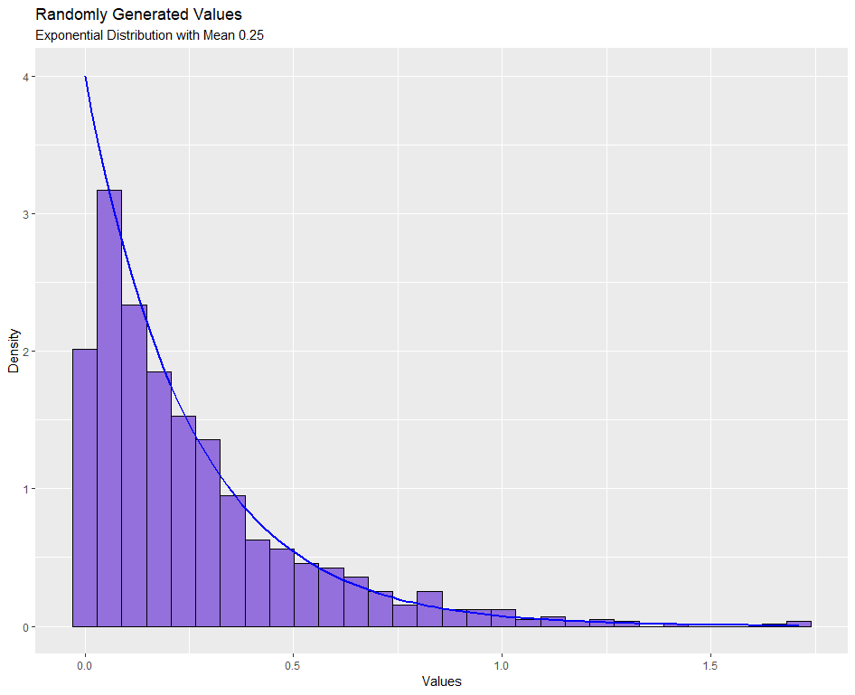

Copy and paste the code you used to complete this exercise into the file you submit along with the generated plot.

## Using a Function to Add Flexibility

It is often useful to create a function that accomplishes the random number generation and plotting tasks we just completed.

Arguments can be used to flexibly specify a wide range of parameters, from the distribution parameter values to the color of the bars in the figure.

Let’s create a function that allows you to specify the mean and standard deviation for the normal distribution from which 1000 random numbers will be generated and plotted.

```r
normplot <- function(mn,sdev) {
  x3 <- rnorm(1000,mn,sdev)
  ggplot(data.frame(x3), aes(x3)) +
    geom_histogram(aes(x=x3, y=after_stat(density)),
                   bins=30,
                   fill="violet",
                   colour="black") +
    labs(x="Values", y="Density") +
    ggtitle(label="Randomly Generated Values",
            subtitle=paste("Normal Distribution with Mean ", mn,
                           " and Standard Deviation ", sdev,sep="")) +
    stat_function(fun = function(x) dnorm(x, mean = mn, sd = sdev),
                  color="blue",
                  linewidth=1)
}
```

Notice the `subtitle` argument that makes use of the `paste` function.

The `paste` function creates strings by pasting together all the arguments prior to the `sep=` argument. The value provided to the `sep=` argument is used as a separator, pasted between the other arguments. We specified `sep=””` to indicate no separator.

This allowed us to create a string containing the values of `mn` and `sdev` rather than the text `“mn”` and `“sdev”` that would have appeared in our subtitle if we’d specified the argument below.

```
subtitle= "Normal Distribution with Mean mn and Standard Deviation sdev”
```

Let’s call our `normplot` function.

```r
normplot(mn=300, sdev=100)
```

[output not shown]

**Exercise 2:**

Turn the code you wrote for Exercise 1 into a function that takes additional arguments allowing the user to flexibly create plots. Include arguments to specify:

- The value of the exponential rate parameter
- The number of random numbers to generate
- The line color
- The fill color

Make sure that all titles appropriately reflect the data being plotted.

Name your function `expplot` and call the function once using argument values of your choosing.

Copy and paste the code you used to complete this exercise into the file you submit along with the generated plot.

Let’s add even more flexibility to our code by allowing the distribution (normal versus exponential) to be specified as an argument. We will also need to include two arguments for distributional parameters even though we will only be using one when the exponential distribution is requested.

```r
norm.or.exp <- function(n,dist,par1,par2) {
  if(dist == "Exponential") {
    x1 <- rexp(n,par1)
    st <- paste("Exponential Distribution with Mean ",1/par1, sep="")
    fn <- function(x) dexp(x, rate = par1)
  } else if(dist == "Normal") {
    x1 <- rnorm(n,par1,par2)
    st <- paste("Normal Distribution with Mean ", par1,
                " and Standard Deviation ", par2,   sep="")
    fn <- function(x) dnorm(x, mean = par1, sd = par2)
  }
  ggplot(data.frame(x1), aes(x1)) +
    geom_histogram(aes(x=x1, y=after_stat(density)),
                   bins=30,
                   fill="lightblue",
                   colour="black") +
    labs(x="Values", y="Density") +
    ggtitle(label="Randomly Generated Values",
            subtitle= st) +
    stat_function(fun = fn,
                  color="black",
                  linewidth=1)
}
```

We can now call this function specifying either `Exponential` or `Normal` and we will get the appropriate plot.

```r
norm.or.exp(1000, "Exponential", 10)
```

[output not shown]

```r
norm.or.exp(1000, "Normal", 10, 3)
```

[output not shown]

**Exercise 3:**

Edit the function we just wrote (`norm.or.exp`) to create a new function called `norm.or.exp.opt`. This new function should take arguments corresponding to the number of random numbers to generate, the mean, and the standard deviation.

If the standard deviation is not specified when calling the function, the function should by default set the standard deviation equal to the mean (which must always be specified).

Rather than letting the user who calls the function specify whether the distribution should be Exponential or Normal, let the decision be made by using the `sample` function (0.40 probability of selecting Exponential and 0.60 probability of selecting Normal) within the `norm.or.exp.opt` function.

Call the function twice with the following arguments:

- First Call: number of random numbers = 1000, mean = 10
- Second Call: number of random numbers = 500, mean = 10, standard deviation = 4

For each call you have a 40% probability of obtaining an exponential plot and a 60% probability of obtaining a normal plot.

Copy and paste the code you used to complete this exercise into the file you submit along with the two generated plots.

## Computing Event Probabilities using Simulation

It is also possible to calculate the probability of simple events using simulation. This is sometimes referred to as *Monte Carlo Simulation*.

Suppose we roll two fair 6-sided die. What is the probability that their sum is 7 or greater?

Obviously, we can figure this out by simply enumerating the 36 (6 x 6) different possible outcomes and counting the number of results that equate to a sum of 7 or higher (1-6, 6-1, 5-2, 2-5, 3-4, 4-3, 6-2, 2-6, 5-3, 3-5, 4-4, 6-3, 3-6, 5-4, 4-5, 6-4, 4-6, 5-5, 6-5, 5-6, 6-6) this would give a theoretical probability equal to 21/36 = 0.583.

For demonstration’s sake, we will show that we can also calculate this probability via simulation.

Let’s create a function that simulates each roll of the die and returns `TRUE` if the sum is *at least 7* and `FALSE` otherwise.

```r
HighRoll <- function(numDice, numSides, targetValue, numTrials){
  apply(matrix(sample(1:numSides, numDice*numTrials, replace=TRUE), nrow=numDice),
        2, sum) >= targetValue
}
```

```r
HighRoll(2,6,7,10)
```

[output not shown]

If we assign this vector of `TRUE`s and `FALSE`s to a vector and calculate the mean across that vector, we can get an estimate of the probability of the sum being greater than or equal to 7.

```r
outcome <- HighRoll(2,6,7,10)
mean(outcome)
```

[output not shown]

```r
outcome <- HighRoll(2,6,7,10000)
mean(outcome)
```

[output not shown]

**Exercise 4:**

Using the `HighRoll` function we wrote previously, make a plot to examine the relationship between the simulation-based estimate of the probability and the number of trials.

Assume you are rolling three 6-sided dice and that you are interested in a sum of 11 or greater (`targetValue = 11`).

The plot you create should be a line graph with the number of trials on the x-axis and the simulation-based estimated probability on the y-axis.

You should calculate and plot estimates for number of trials equal to each integer ranging from 1 to 300.

Please make sure the line graph you produce has a title and appropriate x- and y-axis labels.

Copy and paste the code you used to complete this exercise into the file you submit along with the generated plot.

## Using the `replicate` Function

As you may recall, the sum of $N$ exponentially distributed random variables with the rate $M$ follows a gamma distribution with shape parameter equal to $N$ and scale equal to $1/M$.

We would like to demonstrate this by plotting a histogram of the summed variable (based on the sum of randomly generated exponential variables) and then superimposing a curve of the gamma distribution.

We would like to obtain 10,000 values based on the following set of commands:

```r
N <- 5
M <- 0.1

sum(rexp(n=N, rate=M))
```

Rather than using a `for` loop (which is notoriously slow) we can use the `replicate` function.

```r
reps <- 10000

x1 <- replicate(reps, sum(rexp(n=N, rate=M)))
```

To plot the gamma distribution curve, the following function can be supplied to `ggplot`’s `stat_function` function.

```
function(x) dgamma(x, shape=N, scale=1/M)
```

**Exercise 5:**

Create a function to complete the task described directly above. The function should take arguments `reps`, `N`, and `M` and should result in a plot containing a histogram of random values generated by summing `N` exponential variables with rate `M`.

Over the histogram, plot a curve indicating a gamma distribution with shape `N` and scale `1/M`.

Call this function with the following argument values:

```
reps = 10000
N = 10
M = 0.2
```

Copy and paste the code you used to complete this exercise into the file you submit along with the generated plot.

**Exercise 6:**

Let’s demonstrate that the following statement is true using simulated data:

*If X1 and X2 are independent exponential random variables with rate μ1 and μ2 respectively, then min(X1, X2) is an exponential random variable with rate μ = μ1 + μ2*

Let `X1` and `X2` be independent exponentially distributed random variables. Assume `X1` comes from an exponential distribution with rate 0.3 and that `X2` comes from an exponential distribution with rate 0.2.

Let `M` equal the minimum of `X1` and `X2`. Estimate the probability that `M < 2` using at least 500,000 replicates.

To demonstrate equivalence, use a call to the `pexp` function.

You should obtain two similar values. When you present your estimates, please include 5 digits to the right of the decimal point.

Copy and paste the code you used to complete this exercise into the file you submit.